# Задание 1 (метрики для онлайн-казино)

### 1. Финансовые показатели 💰

| KPI | Формула | Назначение |
| --- | --- | --- |
| **GGR** (Gross Gaming Revenue) | `Общий доход - выигрыши` | Основной индикатор доходности платформы |
| **NGR** (Net Gaming Revenue) | `GGR - бонусы - налоги - платежные комиссии` | Реальная прибыль после всех затрат |
| **ARPU** | `Общий доход / кол-во активных игроков` | Эффективность монетизации аудитории |
| **Payout %** | `(Сумма выигрышей / Сумма ставок) * 100%` | Баланс привлекательности и доходности (оптимум 94-97%) |

**🔍 Аргументация**:  
Финансовая устойчивость — ключевой приоритет. Payout % критически важен:

- > 98% → угроза прибыльности
- <92% → снижение лояльности игроков

### 2. Показатели вовлеченности 🎮

| KPI | Формула | Назначение |
| --- | --- | --- |
| **Retention Rate (D7/D30)** | `Игроки, вернувшиеся через 7/30 дней / Новые игроки` | Удержание аудитории |
| **Avg. Session Duration** | `Общее время игры / кол-во сессий` | Глубина вовлеченности |
| **Stickiness** | `DAU / MAU` | Частота возвратов постоянных игроков |

**🔍 Аргументация**:

- Retention >25% (D7) → высокий потенциал LTV
- Сессии <5 мин → сигнал о проблемах с геймплеем/UX
- Stickiness <20% → требуется пересмотр ретеншн-стратегии

### 3. Игровая активность 🎰

| KPI | Формула | Назначение |
| --- | --- | --- |
| **Bet-to-Player Ratio** | `Сумма ставок / кол-во активных игроков` | Интенсивность игровой активности |
| **Game Popularity Index** | `Доля ставок по каждой игре` | Выявление топовых и убыточных игр |
| **Bonus Utilization Rate** | `Использованные бонусы / Выданные бонусы` | ROI маркетинговых кампаний |

**🔍 Аргументация**:

- Bet-to-Player <$50 → низкая мотивация к игре
- Топ-3 игр должны давать >40% GGR
- Bonus Rate <60% → неэффективность бонусной программы

# Задание 2 (примеры запросов по таблицам в БД clickhouse)

#### Для начало покажем таблицы базы данных в дата фреймах пандаса:

```python
import pandas as pd
```

```python
event_log = pd.read_csv('event_log.csv', sep=';', encoding='utf-8')
```

```python
event_log
```

|  | Наименование поля | Тип данных | Описание |
| --- | --- | --- | --- |
| 0 | event_timestamp | DateTime64 | время события |
| 1 | player_id | Int64 | идентификатор пользователя |
| 2 | play_session_id | Int64 | идентификатор сессии |
| 3 | gadget_id | Int64 | идентификатор устройства |
| 4 | gadget_kind | String | тип устройства |
| 5 | os_name | String | операционная система устройства |
| 6 | country_code | String | код страны (ISO) |
| 7 | activity_name | String | название события |

```python
payment_records = pd.read_csv('payment_records.csv', sep=';', encoding='utf-8')
```

```python
payment_records
```

|  | Наименование поля | Тип данных | Описание |
| --- | --- | --- | --- |
| 0 | transaction_id | Int64 | идентификатор транзакции |
| 1 | player_id | Int64 | идентификатор пользователя |
| 2 | payment_successful | Int8 | статус успеха платежа (1 или 0) |
| 3 | payment_initiated | DateTime64 | дата создания платежа |
| 4 | payment_completed | DateTime64 | дата проведения платежа\nесли NULL, то “1970-0... |
| 5 | payment_currency | String | валюта платежа |
| 6 | amount | Float32 | размер платежа |
| 7 | amount_RUB | Float32 | размер платежа в RUB |

```python
user_info = pd.read_csv('user_info.csv', sep=';', encoding='utf-8')
```

```python
user_info
```

|  | Наименование поля | Тип данных | Описание |
| --- | --- | --- | --- |
| 0 | player_id | Int64 | id пользователя на проекте |
| 1 | contact_email | String | электронная почта пользователя |
| 2 | record_created | DateTime64 | дата регистрации |
| 3 | verification_email_sent | DateTime64 | дата отправки письма с\nподтверждением почты\n... |
| 4 | email_verified | DateTime64 | дата подтверждения почты\nпользователем\nесли ... |
| 5 | country_code | String | код страны (ISO) |

#### запрос 1:

который посчитает количество уникальных устройств и уникальных пользователей по месяцам в период с Июля-2023 по Декабрь-2023 (включительно);

SELECT toStartOfMonth(event_timestamp) AS month, COUNT(DISTINCT gadget_id) AS unique_devices, COUNT(DISTINCT player_id) AS unique_users FROM event_log WHERE event_timestamp BETWEEN '2023-07-01' AND '2023-12-31 23:59:59' GROUP BY month ORDER BY month;

#### запрос 2:

который выведет ТОП-5 стран по количеству зарегистрированных пользователей в 2023 году;

SELECT country_code, COUNT(DISTINCT player_id) AS registered_users FROM user_info WHERE toYear(record_created) = 2023 GROUP BY country_code ORDER BY registered_users DESC LIMIT 5;

#### запрос 3:

который выведет ТОП-5 пользователей по общей сумме платежей, и по каждой стране за 2023 год;

-- 1. Создаем временную таблицу (CTE) с агрегированными платежами пользователей WITH user_payments AS ( SELECT p.player_id, -- ID игрока -- Код страны с обработкой NULL значений (заменяем на 'UNKNOWN') COALESCE(u.country_code, 'UNKNOWN') AS country_code, -- Сумма платежей в RUB с точностью до 2 знаков SUM(CAST(p.amount_RUB AS Decimal(18, 2))) AS total_payments

```
-- Используем LEFT JOIN, чтобы включить всех игроков, даже без записи в user_info
FROM payment_records p
LEFT JOIN user_info u ON p.player_id = u.player_id

-- Условия выборки:
WHERE
    -- Платежи за 2023 год
    p.payment_initiated BETWEEN '2023-01-01' AND '2023-12-31'
    -- Успешные платежи или с неизвестным статусом
    AND (p.payment_successful = 1 OR p.payment_successful IS NULL)

-- Группируем по игроку и стране
GROUP BY p.player_id, u.country_code
```

)

-- 2. Выбираем топ-5 платящих пользователей для каждой страны SELECT country_code, -- Код страны player_id, -- ID игрока total_payments -- Общая сумма платежей

FROM ( -- Вложенный запрос для ранжирования пользователей внутри каждой страны SELECT *, -- Присваиваем ранги пользователям по сумме платежей (по убыванию) -- DENSE_RANK() используется, чтобы не было пропусков в рангах при одинаковых суммах DENSE_RANK() OVER ( PARTITION BY country_code -- Разделяем по странам ORDER BY total_payments DESC -- Сортируем по сумме платежей (от большего к меньшему) ) AS rank FROM user_payments -- Исключаем записи с неизвестной страной (NULL) WHERE country_code IS NOT NULL ) -- Выбираем только топ-5 пользователей для каждой страны WHERE rank <= 5

-- Сортируем результаты: -- 1. По коду страны (в алфавитном порядке) -- 2. По сумме платежей (от большего к меньшему) ORDER BY country_code, total_payments DESC;

#### запрос 4:

который посчитает среднюю продолжительности сессии на сайте за 2023 год;

WITH session_durations AS ( SELECT play_session_id, MAX(event_timestamp) - MIN(event_timestamp) AS duration_sec FROM event_log WHERE toYear(event_timestamp) = 2023 GROUP BY play_session_id ) SELECT AVG(duration_sec) AS avg_session_duration_seconds FROM session_durations;

#### запрос 5:

который посчитает количество уникальных пользователей, посетивших сайт (DAU) по месяцам, которые подтвердили свой email-адрес. Аналитика нужна за период с Июля-2023 по Декабрь-2023 (включительно);

-- Основной запрос для расчета месячной аудитории (MAU) верифицированных пользователей SELECT -- 1. Приводим timestamp события к началу месяца (первое число месяца) -- Это позволяет агрегировать данные по месяцам toStartOfMonth(e.event_timestamp) AS month,

```
-- 2. Считаем количество УНИКАЛЬНЫХ игроков за каждый месяц (DAU - Daily Active Users)
--    DISTINCT гарантирует, что каждый пользователь учитывается только один раз за месяц
COUNT(DISTINCT e.player_id) AS dau
```

-- 3. Берем данные из таблицы событий FROM event_log e

-- 4. Соединяем с таблицей пользователей, чтобы проверить верификацию email JOIN user_info u ON e.player_id = u.player_id

-- 5. Условия выборки: WHERE -- Выбираем события только за второе полугодие 2023 года e.event_timestamp BETWEEN '2023-07-01' AND '2023-12-31 23:59:59'

```
-- 6. Фильтруем только пользователей с подтвержденным email
--    (исключаем записи с дефолтной датой верификации)
AND u.email_verified != '1970-01-01'
```

-- 7. Группируем результаты по месяцам GROUP BY month

-- 8. Сортируем результаты по месяцам в хронологическом порядке ORDER BY month;

#### запрос 6:

который позволит оценить долю (по сумме успешного депозита) пользователей с подтвержденной почтой, в Декабре 2023 года

-- 1. Создаем временную таблицу (CTE) с агрегированной статистикой по платежам WITH payment_stats AS ( SELECT -- Сумма платежей только от пользователей с подтвержденным email: -- Если email верифицирован (дата > 1970-01-01), берем сумму платежа, иначе 0 SUM(CASE WHEN u.email_verified > toDateTime('1970-01-01') THEN p.amount_RUB ELSE 0 END) AS verified_amount, -- Общая сумма всех успешных платежей за период SUM(p.amount_RUB) AS total_amount

```
-- Соединяем таблицы платежей и информации о пользователях
FROM payment_records p
JOIN user_info u ON p.player_id = u.player_id

-- Условия выборки:
WHERE
    -- Платежи только за декабрь 2023 года
    p.payment_initiated BETWEEN '2023-12-01' AND '2023-12-31 23:59:59'
    -- Только успешные платежи
    AND p.payment_successful = 1
```

)

-- 2. Вычисляем итоговый показатель SELECT -- Процент платежей от верифицированных пользователей: -- Делим сумму верифицированных платежей на общую сумму, -- умножаем на 100 для получения процентов -- Используем COALESCE и NULLIF для защиты от деления на ноль: -- - NULLIF(total_amount, 0) вернет NULL если total_amount = 0 -- - COALESCE вернет 0 если результат NULL COALESCE(verified_amount / NULLIF(total_amount, 0) * 100, 0) AS verified_users_payment_percentage FROM payment_stats;

#### запрос 7:

который выведет для каждого пользователя среднее значение, нижний квартиль, медиану и верхний квартиль по времени между успешными депозитами.

-- 1. Создаем временную таблицу (CTE) с успешными платежами и вычисляем время предыдущего платежа для каждого пользователя WITH successful_deposits AS ( SELECT player_id, payment_initiated, -- Время текущего платежа -- Используем оконную функцию LAG чтобы получить время предыдущего успешного платежа этого же игрока LAG(payment_initiated) OVER ( PARTITION BY player_id -- Группируем по игроку ORDER BY payment_initiated -- Сортируем по времени платежа ) AS prev_payment FROM payment_records WHERE payment_successful = 1 -- Только успешные платежи AND toYear(payment_initiated) = 2023 -- Только платежи за 2023 год ),

-- 2. Вычисляем разницу в секундах между текущим и предыдущим платежом time_differences AS ( SELECT player_id, -- Вычисляем разницу в секундах между текущим и предыдущим платежом dateDiff('second', prev_payment, payment_initiated) AS seconds_between_payments FROM successful_deposits WHERE prev_payment IS NOT NULL -- Исключаем первую запись для каждого игрока (у нее нет предыдущего платежа) )

-- 3. Агрегируем статистику по каждому игроку SELECT player_id, -- Среднее время между платежами (в секундах) AVG(seconds_between_payments) AS avg_seconds, -- Первый квартиль (25% платежей происходят быстрее этого значения) quantile(0.25)(seconds_between_payments) AS q1_seconds, -- Медиана (50% платежей происходят быстрее этого значения) quantile(0.5)(seconds_between_payments) AS median_seconds, -- Третий квартиль (75% платежей происходят быстрее этого значения) quantile(0.75)(seconds_between_payments) AS q3_seconds FROM time_differences GROUP BY player_id -- Группируем результаты по игроку ORDER BY player_id; -- Сортируем по ID игрока

# Задание 3 (манипуляции данными в Python)

Есть таблица с действиями пользователей A/B-теста (*task_3_events.parquet*):

$events$ - посещение пользователем сайта

- $user\_id$ - id юзера,
- $user\_group$ - группа A/B-теста,
- $time$ - время совершения действия,

Пользовательская сессия определяется по следующим правилам:

1. Новая сессия начинается после 30 минут бездействия.

**Постройте таблицу с сессиями юзеров в формате**:****

- $user\_id$ - id юзера
- $ab\_group$ - группа A/B-теста,
- $session\_start$ - время старта сессии,
- $session\_end$ - время окончания сессии,
- $session\_date$ - дата сессии.

# Задание 3 (оценка АБ-теста)

Был проведен A/B-тест.  
В качестве данных используйте таблицу, построенную в предыдущем задании. Первая сессия юзера считается моментом попадания в A/B-тест.  
Ключевая метрика эксперимента - конверсия во вторую сессию.  
Сделайте вывод о том, какая группа выиграла в A/B-тесте. Ответ обоснуйте.

```python
# Вариант 1: Установка pyarrow
# !pip install pyarrow

# ИЛИ Вариант 2: Установка fastparquet
# !pip install fastparquet
```

#### Построение таблицы сессий

```python
import pandas as pd
import numpy as np
```

```python
# Чтение файла с указанием движка
try:
    # Пробуем pyarrow (приоритетный вариант)
    df = pd.read_parquet('task_3_events.parquet', engine='pyarrow')
except:
    # Если не сработает, пробуем fastparquet
    df = pd.read_parquet('task_3_events.parquet', engine='fastparquet')
```

```python
df.head(3)
```

|  | user_id | user_group | time |
| --- | --- | --- | --- |
| 0 | test_user_68722185 | 0 | 2023-12-01 00:00:02.465889 |
| 1 | test_user_50279722 | 1 | 2023-12-01 00:00:02.490361 |
| 2 | test_user_68722185 | 0 | 2023-12-01 00:00:03.803897 |

```python
df.describe()
```

|  | user_group | time |
| --- | --- | --- |
| count | 835357.000000 | 835357 |
| mean | 0.494623 | 2023-12-07 23:20:34.454262272 |
| min | 0.000000 | 2023-12-01 00:00:02.465889 |
| 25% | 0.000000 | 2023-12-04 09:54:34.656788992 |
| 50% | 0.000000 | 2023-12-08 08:47:36.735497984 |
| 75% | 1.000000 | 2023-12-11 15:04:35.717595904 |
| max | 1.000000 | 2023-12-14 13:14:44.878850 |
| std | 0.499971 | NaN |

```python
# Сортировка по user_id и времени
df = df.sort_values(['user_id', 'time'])
```

```python
# Определение новых сессий (30 минут бездействия)
df['time_diff'] = df.groupby('user_id')['time'].diff()
df['new_session'] = (df['time_diff'] > pd.Timedelta(minutes=30)) | (df['time_diff'].isna())
```

```python
# Нумерация сессий
df['session_num'] = df.groupby('user_id')['new_session'].cumsum()
```

```python
# Группировка по сессиям
sessions = df.groupby(['user_id', 'user_group', 'session_num']).agg(
    session_start=('time', 'min'),
    session_end=('time', 'max')
).reset_index()
```

```python
# Добавление даты сессии
sessions['session_date'] = sessions['session_start'].dt.date
```

```python
# Переименование колонок
sessions = sessions.rename(columns={'user_group': 'ab_group'})
sessions = sessions[['user_id', 'ab_group', 'session_start', 'session_end', 'session_date']]
```

```python
# Сохранение результата
sessions.to_parquet('user_sessions.parquet', index=False)
```

```python
# таблица сессий
sessions.head(5)
```

|  | user_id | ab_group | session_start | session_end | session_date |
| --- | --- | --- | --- | --- | --- |
| 0 | test_user_10021823 | 1 | 2023-12-07 01:08:51.008309 | 2023-12-07 01:10:11.804765 | 2023-12-07 |
| 1 | test_user_10030144 | 0 | 2023-12-02 20:37:34.861127 | 2023-12-02 20:38:14.301560 | 2023-12-02 |
| 2 | test_user_1003396 | 1 | 2023-12-01 00:00:48.238407 | 2023-12-01 00:01:41.376842 | 2023-12-01 |
| 3 | test_user_1003396 | 1 | 2023-12-02 08:21:13.134305 | 2023-12-02 08:35:03.351138 | 2023-12-02 |
| 4 | test_user_1003396 | 1 | 2023-12-02 21:12:09.512252 | 2023-12-02 21:34:53.437896 | 2023-12-02 |

#### Оценка A/B-теста

```python
# Определение первой сессии каждого пользователя
first_sessions = sessions.sort_values('session_start').groupby('user_id').first().reset_index()
```

```python
# Фильтрация пользователей, которые попали в тест (имеют первую сессию)
test_users = first_sessions[['user_id', 'ab_group']]
```

```python
# Подсчет количества сессий для каждого пользователя
user_session_counts = sessions.groupby('user_id').size().reset_index(name='session_count')
```

```python
# Объединение данных
conversion_data = pd.merge(test_users, user_session_counts, on='user_id', how='left')
```

```python
# Определение конверсии (имеет ли пользователь ≥2 сессий)
conversion_data['converted'] = (conversion_data['session_count'] >= 2).astype(int)
```

```python
# Расчет конверсии по группам
ab_results = conversion_data.groupby('ab_group').agg(
    users=('user_id', 'count'),
    conversions=('converted', 'sum')
).reset_index()

ab_results['conversion_rate'] = ab_results['conversions'] / ab_results['users']
```

```python
# загрузка библиотеки для анализа статистических метрик
# !pip install statsmodels
```

```python
# Статистическая значимость (Z-тест)
from statsmodels.stats.proportion import proportions_ztest

count = ab_results['conversions'].values
nobs = ab_results['users'].values
z_stat, p_value = proportions_ztest(count, nobs)

print(f"Конверсия в группе A: {ab_results.loc[0, 'conversion_rate']:.2%}")
print(f"Конверсия в группе B: {ab_results.loc[1, 'conversion_rate']:.2%}")
print(f"p-value: {p_value:.4f}")
```

```
Конверсия в группе A: 24.67%
Конверсия в группе B: 25.00%
p-value: 0.6421
```

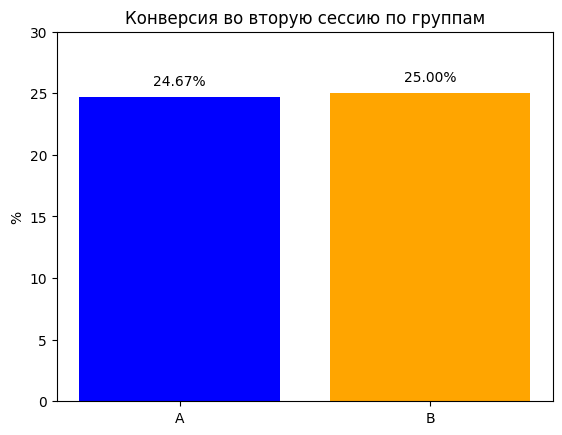

```python
import matplotlib.pyplot as plt
plt.bar(x=['A', 'B'], height=[24.67, 25.00], color=['blue', 'orange'])
plt.ylim(0, 30)
plt.title('Конверсия во вторую сессию по группам')
plt.ylabel('%')
plt.text(0, 24.67+1, '24.67%', ha='center')
plt.text(1, 25.00+1, '25.00%', ha='center')
plt.show()
```